# L19

# Hidden Markov Model (HMM) Inference

$$B_{t}(X)=\mathbb{P}(X_{t}|e_{1:t})$$
- Two steps: 1. Passage of time 2. Observation - Belief is the belief of the next state - $B'$ is the belief without observing any new evidence - Step before evaluating $B$ - Once you observe the new evidence at that time, you evaluate $B$ - Given $B(X_{t})=\mathbb{P}(X_{t}|e_{1:t})$ and $\mathbb{P}(X_{t+1}|x_{t})$
$$P(X_{t+1}|e_{1:t})=\sum_{x_{t}}\mathbb{P}(X_{t+1},x_{t}|e_{1:t})=\sum_{x_{t}}\mathbb{P}(X_{t+1}|x_{t})\mathbb{P}(x_{t}|e_{1:t})=\sum_{x_{t}}\mathbb{P}(X_{t+1}|x_{t})B(x_{t})$$
$$B'(X_{t+1})=\mathbb{P}(X_{t+1}|e_{1:t})$$
$$B(X_{t+1})\propto_{X_{t+1}}{\mathbb{P}(e_{t+1}|X_{t+1})B'(X_{t+1})}$$
- Note: have to re-normalize all proportionalities

## Example

- Given $\mathbb{P}(X_{1})$ and $\mathbb{P}(X_{2}|X_{1})$
  $$\mathbb{P}(x_{2})=\sum_{x_{1}}\mathbb{P}(x_{1},x_{2})=\sum_{x_{1}}\mathbb{P}(x_{1})\mathbb{P}(x_{2}|x_{1})$$
  $$\mathbb{P}(x_{1}|e_{1})=\frac{\mathbb{P}(x_{1},e_{1})}{\mathbb{P}(e_{1})}\propto_{X_{1}}{\mathbb{P}(x_{1},e_{1})}=\mathbb{P}(x_{1})\mathbb{P}(e_{1}|x_{1})$$
  Explicitly:
  $$\mathbb{P}(x_{1}|e_{1})=\frac{\mathbb{P}(x_{1})\mathbb{P}(e_{1}|x_{1})}{\sum_{x'}\mathbb{P}(x')\mathbb{P}(e_{1}|x')}$$

## Online Belief Updates

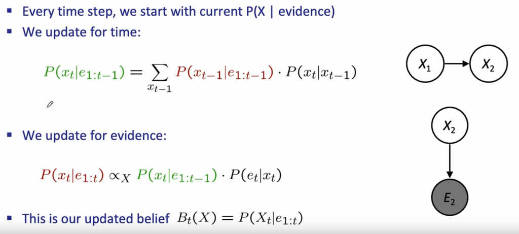

## Concrete Example

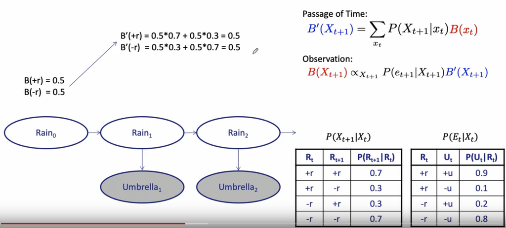

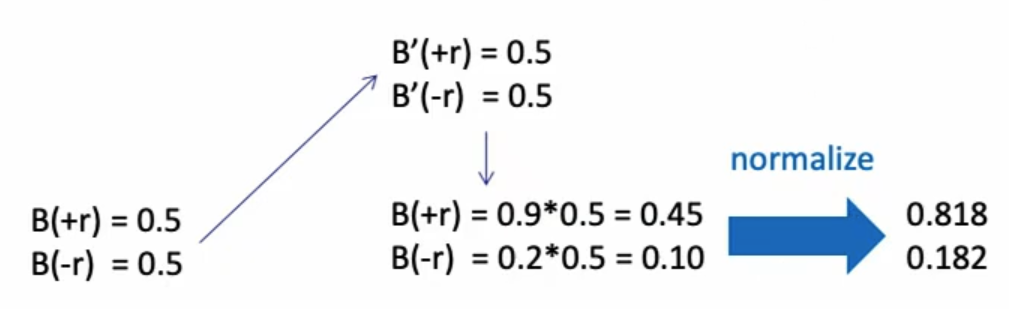

## Particle Filtering (Approximate Inference)

- Filtering ≙ approximate solution
- Sometimes $|X|$ is too big to use exact inference
  - $|X|$ may be too big to even store $B(X)$
  - eg: $X$ is continuous
- Probability of some state is given by the amount of particles that occupy it
  - Sample ⟺ Particle
  - Track samples of $X$, not all values
  - Time per step is linear in the number of samples
  - Number of samples needed may be large
  - In memory: list of particles, not states
- Keep track of $N$ particles; representation of $P(X)$ is just a list of those particles
  - $N\ll{|X|}$
  - Storing map from $X$ to counts would defeat point
- $P(x)$ approximated by number of particles with value x
  - Many $x$ have $P(x)=0$
  - More particles ⟹ more accuracy

- Each particle is moved by sampling its next position from the transition model: $x'=\textrm{sample}(\mathbb{P}(X'|x))$
- With enough samples, the before and after values are consistent

#### Weighting

- Don’t sample observation, fix it
  $$w(x)=\mathbb{P}(e|x)$$
  $$B(X)\propto{\mathbb{P}(e|X)B'(X)}$$
- Probabilities have been down-weighted (they sum to $N$ times an approximation of $\mathbb{P}(e)$)
  - Need to normalize
- Instead of tracking weighted samples, resample at each step
  - $N$ times, we choose form our weighted sample distribution (draw with replacement)
  - Equivalent to re-normalizing the distribution
  - Completes the update for this time step
- **IDEA**: track samples of states rather than an explicit distribution

## Dynamic Bayes’ Nets

- Can track multiple variables over time using multiple sources of evidence
- Idea: repeat a fixed BN at each time
- Variables from time $t$ can condition on those from $t-1$
- Variable elimination applies
  - Procedure: ‘unroll’ the network for $T$ time steps, then eliminate variables until $\mathbb{P}(X_{T}|e_{1:t})$ is computed